[← Back to All Parables](https://www.kameronyork.com/parables/)

# The Growing Seed

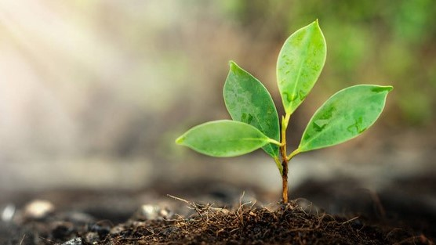

#### Reference:

[Mark 4:26-29](https://www.churchofjesuschrist.org/study/scriptures/nt/mark/4?lang=eng&id=26-29#p26)

#### Insights here:

This article is yet to be completed. Please check back later!

**Points:**  
- The ways of God are a process. In my experience revelation comes over time. Something I learned years ago will build upon itself, gaining more knowledge until I reach a higher level of understanding. It is not often that a spiritual lightning bolt hits and suddenly someone has a perfect understanding.  
- A lot of interpretations of this parable take the meaning to be building the kingdom of God through missionary work. I personally like an interpretation of the parable that describes how the seed is the Spirit of God growing in people. It will grow over time, but the process of how, why, and when the spirit will grow within a person is unknown to man.  
- A major part of the parable is the narrative of the farmer. “A certain man…” planted seed (plural) in a field. Then a period of time goes by (interesting that it is not mentioned how much time passes, or what the farmer (our main character) is doing during this time period), and the seeds start to grow. The growth is described as a process (like the process of revelation). Then, after the seeds are grown the maturity, the farmer reaps the harvest - immediately.  
- Does it have anything to do with the verse preceeding the parable? The verse prior reads, “For he that hath, to him shall be given: and he that hath not, from him shall be taken even that which he hath.” Then, right at the beginning of the parable, the Lord says, “…So is the kingdom of God…”. It is interesting that the parable is about a person who starts with a small amount (seeds), then - after planting them - reaps a lot more than what he started with. So, like what is stated in verse 25, the man started with an amount and was given more.

[output not shown]